# STAT 410 Lab Mod 2

Original Author Prof. Kristin Duncan, Code by Brandon Miner

Some exercises from “Introduction to Data Science” by Irizarry

## 1

Have tidyverse installed and loaded. Install and load the dslabs package so that you can access the murders dataset from dslabs. You’ll see it contains variables state, abb, region, populations, and total.

- Use the function mutate to add a murders column named rate with the per 100,000 murder rate. Use assignment to create a newly named version of the data frame that will keep the rate column.
- rank(x) gives you the ranks of x from lowest to highest, and rank(-x) gives you the ranks from highest to lowest. Use the function mutate to add a column rank containing the rank from highest to lowest murder rate to your new data frame.

```r
ranked_murders = murders |>
  mutate(rate = total/population*100000) |>
  mutate(rank = rank(-rate))
ranked_murders
```

```
##                   state abb        region population total       rate rank
## 1               Alabama  AL         South    4779736   135  2.8244238   23
## 2                Alaska  AK          West     710231    19  2.6751860   27
## 3               Arizona  AZ          West    6392017   232  3.6295273   10
## 4              Arkansas  AR         South    2915918    93  3.1893901   17
## 5            California  CA          West   37253956  1257  3.3741383   14
## 6              Colorado  CO          West    5029196    65  1.2924531   38
## 7           Connecticut  CT     Northeast    3574097    97  2.7139722   25
## 8              Delaware  DE         South     897934    38  4.2319369    6
## 9  District of Columbia  DC         South     601723    99 16.4527532    1
## 10              Florida  FL         South   19687653   669  3.3980688   13
## 11              Georgia  GA         South    9920000   376  3.7903226    9
## 12               Hawaii  HI          West    1360301     7  0.5145920   49
## 13                Idaho  ID          West    1567582    12  0.7655102   46
## 14             Illinois  IL North Central   12830632   364  2.8369608   22
```

[output cut: 37 more lines]

## 2

Use filter to show the top 5 states with the highest murder rates. Use select so that only state, rate, and rank are printed.

```r
ranked_murders |>
  filter(rank <= 5) |>
  select(rank, state, rate) |>
  arrange(desc(rate))
```

```
##   rank                state      rate
## 1    1 District of Columbia 16.452753
## 2    2            Louisiana  7.742581
## 3    3             Missouri  5.359892
## 4    4             Maryland  5.074866
## 5    5       South Carolina  4.475323
```

## 3

More filtering

- Create a new data frame called murders_nw with only the states from the Northeast and the West.
- How many state are in this category? (use code to answer)
- Use filter and select to create a data frame called my_states of states in these regions with murder rates less than 1. Include columns state, rate, and rank.
- Use arrange to print mystates in descending order of rank.

```r
murders_nw = ranked_murders |>
  filter(region == "Northeast" | region == "West")

print(nrow(murders_nw))
```

```
## [1] 22
```

```r
my_states = murders_nw |>
  filter(rate < 1) |>
  select(rank, state, rate)
my_states |>
    arrange(desc(rank))
```

```
##   rank         state      rate
## 1   51       Vermont 0.3196211
## 2   50 New Hampshire 0.3798036
## 3   49        Hawaii 0.5145920
## 4   46         Idaho 0.7655102
## 5   45          Utah 0.7959810
## 6   44         Maine 0.8280881
## 7   43       Wyoming 0.8871131
## 8   42        Oregon 0.9396843
```

## 4

Use group_by (or .by) and summarise to find the average and standard deviation of murder rates by region

```r
ranked_murders |>
  group_by(region, .add=TRUE) |>
  summarise(mean_rate = mean(rate), sd_rate = sd(rate))
```

```
## # A tibble: 4 × 3
##   region        mean_rate sd_rate
##   <fct>             <dbl>   <dbl>
## 1 Northeast          1.85    1.17
## 2 South              4.42    3.37
## 3 North Central      2.18    1.44
## 4 West               1.83    1.17
```

## 5

Install and load ggrepel. Check out the help menu for ggrepel to learn how to use geom_text_repel in concert with a label aesthetic.

- Use ggplot2 to make a scatterplot of population and total for the murders data set.
- Transform both population and murders total to log scale and replot.
- Add a title (US Gun Murders 2010) and axis labels
- Add the state abbreviations as labels using the repel package
- Color code the points by region
- Add a single best fit line to the plot

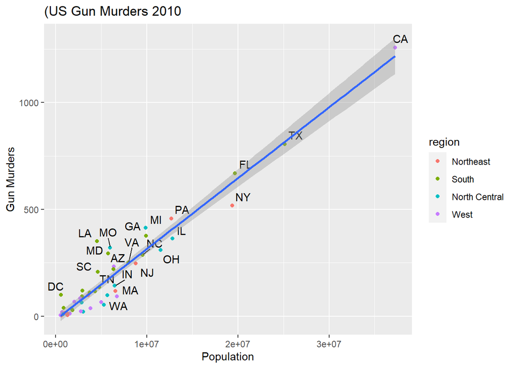

```r
ggplot(ranked_murders, aes(x=population, y=total)) +
  geom_point(aes( color=region)) +
  labs(
    title = "(US Gun Murders 2010",
    x = "Population", y= "Gun Murders"
  ) +
  geom_text_repel(label=murders$abb, max.overlaps = 14) +
  geom_smooth(method="lm")
```

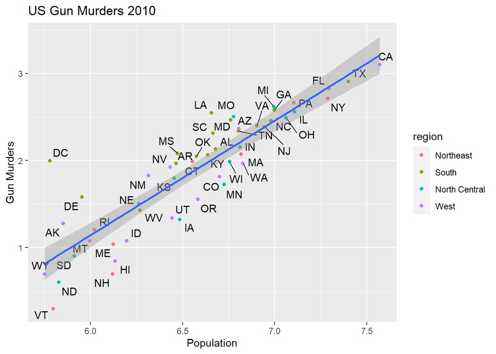

```r
ggplot(murders, aes(x=log10(population), y=log10(total))) +
  geom_point(aes(color=region)) +
  labs(
    title = "US Gun Murders 2010",
    x = "Population", y= "Gun Murders"
  ) +
  geom_text_repel(label=murders$abb, max.overlaps = 14) +
  geom_smooth(method="lm")
```

## 6

The flights data from the package nycflights13 was used in Chapter 3 of R for Data Science 2e. Investigate how flight delays vary by time of day.

- Produce a plot of scheduled departure time of day versus delay in arrival time. Comment on what you see.
- Explore whether the pattern is different for different carriers and departure airports in any way you choose. You should remove the smaller carriers from the data frame before doing this (AS, F9, HA, OO). Comment on what you learned.

[figure not shown]

```r
ggplot(flights, aes(x=sched_dep_time, y=arr_delay)) +
  geom_point(aes(color = carrier)) +
  facet_wrap(origin)
```

The first thing I noticed was that the scheduled departure times are at nice intervals which makes the graph have those vertical lines of no flights. The second thing I noticed was that there seems to be a wide bell curve that covers most flights aside from some flights which I would consider not-completely-outliers. These not-completely-outliers, or to-be-determined-outliers, seem to be mostly Delta flights, but this does not directly indicate that the average Delta flights is delayed because there are plenty of Delta flights that arrive under the curve as seen near the end of said curve. American Airlines also appears above the main grouping